# Tarea 3: Elección de $\lambda$ óptimo

Angie Rodríguez Duque & César Saavedra Vanegas

Octubre 14 de 2020

# Introducción

En los métodos de regresión no paramétrica los estimadores en general no son insesgados, por lo que la varianza del estimador no será suficiente para evaluar la incertidumbre inherente a estos métodos.

De acuerdo a lo anterior, el presente documento tiene como objetivo responder a la pregunta: ¿Cuál valor de $\lambda$ sería una “buena elección”?, para ello se hará uso del estimador rice y del estimador UBRE.

## 1. Base de datos

La base de datos empleada se denomina “Vino Rojo”. Este conjunto de datos de vino tinto consta de 1599 observaciones y 12 variables, 11 de las cuales son sustancias químicas.

## 2. Muestra aleatoria

Se procede a seleccionar una muestra de 60 vinos de la base de datos y se escoge las variables “acidez fija” como respuesta y “ph” como predictora

```r
# Tamaño de la muestra
n <- 60
# Seleccion de la muestra
set.seed(12345)
muestra <- Datos %>% sample_n(size=n,replace=FALSE)
muestra <- muestra %>% arrange(pH)
```

### Representación gráfica

A continuación se procede a graficar el comportamiento de diagrama de dispersion

```r
x <- muestra  %>% dplyr::select(fixed.acidity, pH)
```

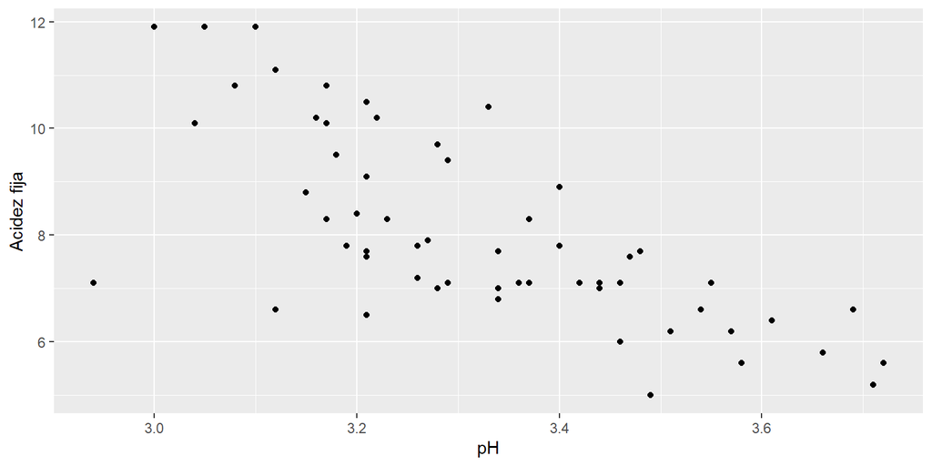

```r
ggplot() + geom_point(data = x, aes(x = pH, y = fixed.acidity)) +
  ylab("Acidez fija") + xlab("pH")
```

## 3. Estimación de la varianza $(\hat{\sigma}^{2})$

$$\sigma^{2}_{R}=\displaystyle{\frac{1}{2(n-1)}\sum_{i=2}^{n}\left( y_{i}-y_{i-1}\right)^{2}}$$

## 4. Elección de $\lambda$

La elección del $\lambda$ más apropiado para la estimación de $\mu$ en el ejemplo de vino rojo se lleva a cabo mediante el estimador insesgado del riesgo, también conocido como **UBRE** (UnBiased Risk Estimator) el cual hace uso de series de cosenos.

$$\hat{R}(\lambda)=\frac{1}{n}RSS(\lambda)+\frac{2}{n}\hat{\sigma}^{2}tr\left[S_{\lambda}\right]-\hat{\sigma}^{2}$$

Deseamos entonces construir un dataframe tomando como variable respuesta “acidez fija” y como variable predictora “pH” donde f es la base de cosenos (CONS) que elegimos previamente.

```r
lambda <- 30
all.R <- all.R(x, lambda)
all.R
```

| UBRE | CV | GCV | LAMBDA |
| --- | --- | --- | --- |
| 0.2374374 | 1.679390e+00 | 1.688573 | 2 |
| 0.1963344 | 1.629180e+00 | 1.649753 | 3 |
| 0.2190494 | 1.651224e+00 | 1.680319 | 4 |
| 0.2292779 | 1.656378e+00 | 1.697177 | 5 |
| 0.2336055 | 1.644459e+00 | 1.706858 | 6 |
| 0.2812813 | 1.686110e+00 | 1.771622 | 7 |
| 0.3249054 | 1.736705e+00 | 1.834760 | 8 |
| 0.3687135 | 1.804683e+00 | 1.901791 | 9 |
| 0.4141164 | 1.895187e+00 | 1.975067 | 10 |
| 0.4592090 | 1.966977e+00 | 2.052335 | 11 |

[output cut: 19 more lines]

### Selección de $\lambda$

Ahora, tenemos la estimación del comportamiento de la acidez fija de acuerdo al pH de los vinos usando series de Fourier con base de cosenos y con un $\lambda=3$, el cual fue seleccionado por medio del método UBRE. A partir de lo anterior, se puede decir que $\hat{\mu}_3$ es una buena aproximación a $\mu$.

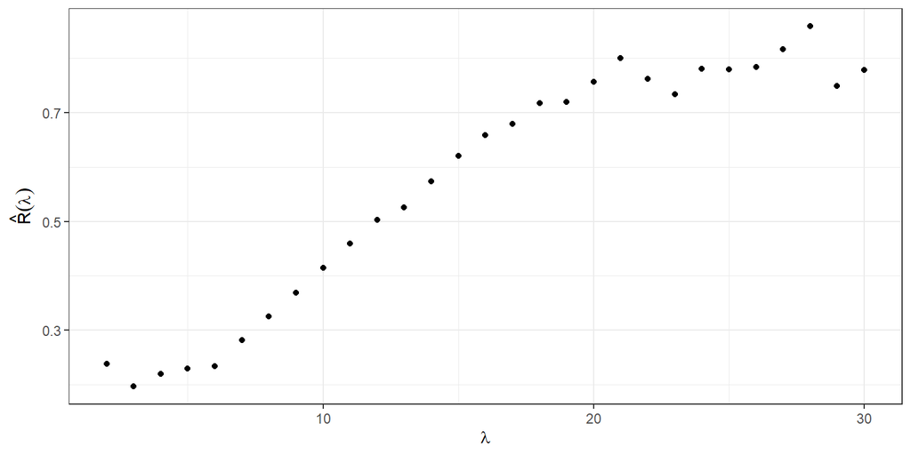

```r
ggplot()+
  geom_point(data = all.R, aes(x = LAMBDA, y = UBRE)) +
  theme_bw() +
  labs(x =  expression(lambda), y = expression(hat(R)(lambda)))
```

Finalmente se observa mediante los graficos que el valor de $\lambda$ que minimiza las estimaciones segun el criterio de UBRE es un valor de $\lambda=3$.

## 5. Estimación del modelo de regresión no paramétrica

### Representación de $\mu_{3}(X)$

Se observa el ajuste con $\lambda=3$ con los datos reales (puntos) y los datos ajustados por el modelo (línea) de la variable “Acidez fija” vs “pH”.

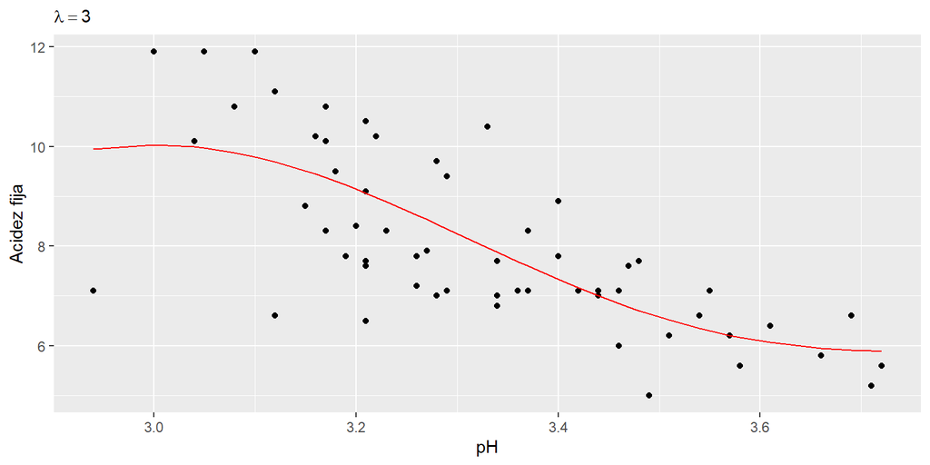

```r
ggplot()+ geom_point(data = x, aes(x = pH, y = fixed.acidity)) +
  geom_line(data = x, aes(x =pH, y = fitted), col="red") +
  labs(subtitle = expression(lambda==3)) +
  ylab("Acidez fija") + xlab("pH")
```

Tenemos entonces la estimación del comportamiento de la acidez fija para el pH usando series de Fourier con base de cosenos y con un $\lambda=3$, que seleccionamos por medio del método UBRE, podríamos decir que $\mu_{3}$ es una buena aproximación a $\mu$.

# Bibliografía

- Olaya, J. (2012). Métodos de Regresión No Paramétrica. Universidad del Valle.
- R Core Team. (2013). R: A Language and Environment for Statistical Computing. R Foundation for Statistical Computing. http://www.r-project.org/
- Eubank (1999), Nonparametric Regression and Spline Smoothing, second edn, Marcel Dekker, New York, NY